# Comparing 2020 Campaign Staff Online Presence

2019-11-22

I wanted to see how active campaign staffers are on social media. Looking at only the communications and press staff of candidates who particpated in NBC’s debate on Nov 21, I considered their twitter presence on debate day.

[This](https://ballotpedia.org/Presidential_election_key_staffers,_2020) is the list I used to get staffers’ Twitter handles. All of the candidates have two communications/press staffers, except Booker who has three, and Biden who has four.

Yang and Gabbard actually each have one comms staffer, but Yang’s hasn’t tweeted since June, and Gabbard’s hasn’t tweeted since August. So they don’t show up for the rest of my analysis.

Here are the findings:

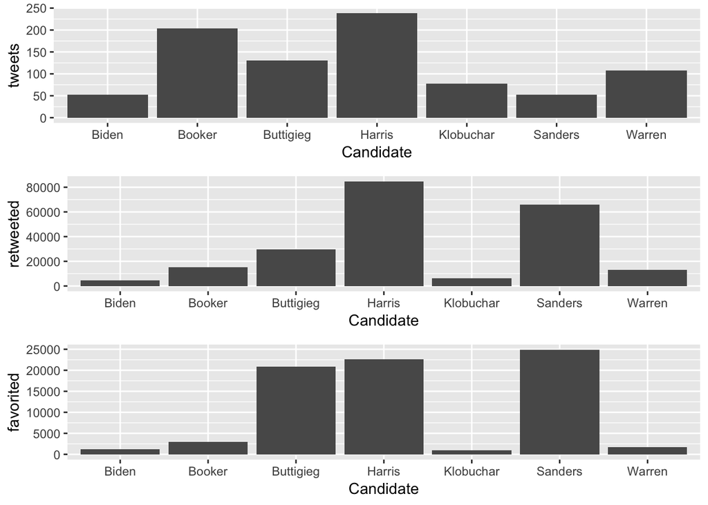

Apparently, Biden’s team of four couldn’t keep up with any of the others. The 53 tweets his team did get out on debate day didn’t manage to gain much traction. Klobuchar and Warren’s situations were similar.

Booker’s team, on the other hand, was pretty active on Twitter that day. But despite the volume, they didn’t gain much traction either.

Sanders experience the opposite: low-activity but high visibility.

Harris’s team’s Twitter game was strongest, as was her traction.